# Data Analysis Assignment

Osama Jerome

# Problem 1

*Read in all three data sets into R as indicated in the directions above. You should have three data frames in your R environment: bls, SP 500, and the data frame of unemployment rates. Tidy the unemployment-rates data frame. When tidying this data frame, one of the columns in this final data frame should be the date, e.g., “Jan 2010”. Convert all dates, as well as year-month combinations, to have the Date data type. For year-month combinations, assume that you’re working with the first day of the month. Make sure that all columns in all data frames have appropriate data types (e.g., numbers should be numeric).*

## Read in Bls Release dates

```r
source("BLS_Release_Dates.R")
bls$Date<-as.Date(bls$Date, "%A, %B %d, %Y")
head(bls)
```

```
##         Date    Time                                  Release
## 1 2007-01-05 8:30 AM   Employment Situation for December 2006
## 2 2007-02-02 8:30 AM   Employment Situation for January 2007
## 3 2007-03-09 8:30 AM Employment Situation for February 2007
## 4 2007-04-06 8:30 AM     Employment Situation for March 2007
## 5 2007-05-04 8:30 AM      Employment Situation for April 2007
## 6 2007-06-01 8:30 AM        Employment Situation for May 2007
```

## Read in Unemployment report

```r
library(readxl)
library(dplyr)
library(lubridate)

sru<-read_xlsx("SeriesReport-20201006201227_5de657.xlsx")
sru<-as.data.frame(sru)
sru <- sru[-c(1:11),]

df<- data.frame(Year = numeric(), Month = character(), Unemployment = numeric())
for(j in 1:12){
  for(i in 2:12){
    row<- c(sru[i,1], sru[1,j+1], sru[i,j+1])
    df <- rbind(df, row)
  }
}
rm(i,j)
df <- df %>%
  rename(
    Year = X.2010.,
    Month = X.Jan.,
    Unemployment=X.9.800000000000001.
  )
df<-df %>% arrange(Year)


df$Month <- gsub("Jan", "01 Jan", df$Month)
df$Month <- gsub("Feb", "01 Feb", df$Month)
df$Month <- gsub("Mar", "01 Mar", df$Month)
df$Month <- gsub("Apr", "01 Apr", df$Month)
df$Month <- gsub("May", "01 May", df$Month)
df$Month <- gsub("Jun", "01 Jun", df$Month)
df$Month <- gsub("Jul", "01 Jul", df$Month)
df$Month <- gsub("Aug", "01 Aug", df$Month)
df$Month <- gsub("Sep", "01 Sep", df$Month)
df$Month <- gsub("Oct", "01 Oct", df$Month)
df$Month <- gsub("Nov", "01 Nov", df$Month)
df$Month <- gsub("Dec", "01 Dec", df$Month)
df$Month = paste(df$Month,df$Year)
df$Year<-NULL
df$Month<- as.character(df$Month)

df$Month<- as.Date(df$Month, "%d %b %Y" )
df$Unemployment<-as.numeric(df$Unemployment)
df$Month <- df$Month %m+% months(1)
head(df)
```

```
##        Month Unemployment
## 1 2010-02-01          9.8
## 2 2010-03-01          9.8
## 3 2010-04-01          9.9
## 4 2010-05-01          9.9
## 5 2010-06-01          9.6
## 6 2010-07-01          9.4
```

## Read in SP_500

```r
library(quantmod)
getSymbols("^GSPC", src = "yahoo")
```

```
## [1] "^GSPC"
```

```r
SP_500 <- Cl(GSPC)
rm(GSPC)
SP_500 <- as.data.frame(SP_500)
SP_500 <- tibble::rownames_to_column(SP_500, var = "Date")
SP_500$Date <- as.Date(SP_500$Date)
head(SP_500)
```

```
##         Date GSPC.Close
## 1 2007-01-03    1416.60
## 2 2007-01-04    1418.34
## 3 2007-01-05    1409.71
## 4 2007-01-08    1412.84
## 5 2007-01-09    1412.11
## 6 2007-01-10    1414.85
```

# Problem 2

Reformat the data frames provided above so that you have only one data frame, consisting of the following columns:  
• The dates on which the employment numbers have been released  
• The closing stock prices of the S&P 500 on the corresponding dates  
• The unemployment rate announced on the corresponding dates  
All observations that do not occur on the dates on which the employment numbers have been released should be dropped.

```r
bls<-bls %>% filter(grepl("Employment Situation for", bls$Release) & grepl("200",bls$Release)==FALSE)

SP_500<-SP_500[match(bls$Date, SP_500$Date),]

df<-df[-c(132),]

my_data<-bls
my_data["Unemployment"]<-df$Unemployment
my_data<-merge(my_data, SP_500)
my_data$Unemployment<-as.numeric(my_data$Unemployment)
my_data$Time<-NULL
my_data$Release<-NULL
head(my_data)
```

```
##         Date Unemployment GSPC.Close
## 1 2010-02-05          9.8    1066.19
## 2 2010-03-05          9.8    1138.70
## 3 2010-05-07          9.9    1110.88
## 4 2010-06-04          9.6    1064.88
## 5 2010-07-02          9.4    1022.58
## 6 2010-08-06          9.4    1121.64
```

The match function just goes through the date column of the SP_500 dataset and remove the dates that don’t match the dates in the date column of the BLS dataset. Here is the source of where I found it and how to use it. Its a tutorial on the match function. https://www.youtube.com/watch?v=NcqsK9JeEJI

# Problem 3

*Using `ggplot2`, plot line graphs of the unemployment rates and S&P 500 data with release date on the x-axis from the data frame in the prior problem. Use appropriate axis labels and a black-and-white theme.*

```r
library(dplyr)
library(ggplot2)
```

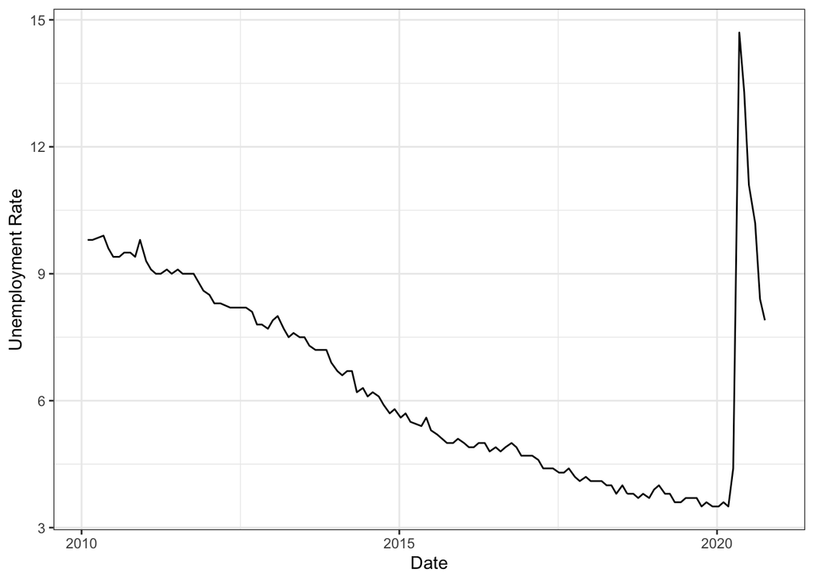

```r
ggplot(my_data, aes(x = Date, y = Unemployment))+geom_line()+theme_bw()+ylab("Unemployment Rate")
```

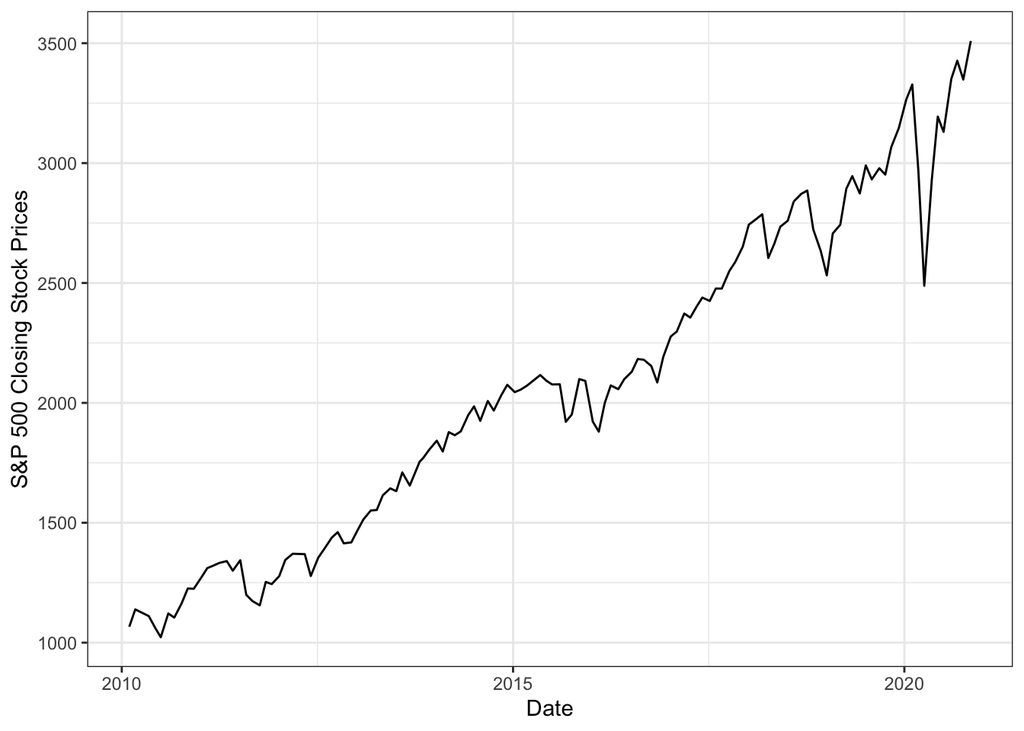

```r
ggplot(my_data, aes(x = Date, y = GSPC.Close))+geom_line()+theme_bw()+ylab("S&P 500 Closing Stock Prices")
```

# Problem 4

*Is there a correlation between the unemployment rate reported and the S&P 500 closing prices on these reporting dates? Interpret using Kendall’s τ (tau).*

```r
cor(my_data$Unemployment, my_data$GSPC.Close, method = "kendall", use = "complete.obs")
```

```
## [1] -0.7510387
```

There seems to be a strong negative correlation between closing stock prices and unemployment rates.